# MEI Mutation Rate, Enrichment, and Figure 4

- This code makes all input figures for Figure 4 of Gardner et. al. Controbution of Retrotransposition to Developmental Disorders (2019)
- All Figures need some cleaning up and processing in Illustrator
- All files/code are located in: `/Users/eg15/Documents/Current Projects/DDD/Manuscript/Figures/Figure2/`

Load all libraries necessary for this notebook to work and setup basic stuff:

- libraries
- default graphpad-like theme
- function for calculating confidence intervals

# Mutation rate calculation

Code will generate the total number of variants that we expect in *n* individuals based on mutation rates calculated from the waterson estimator presented in Table 2 of the main text. Numbers for input into the Watterson estimator/mutation rate calculator are generated seperately for the DDD and 1KGP.

## Accessibility Masks

### DDD Accessible Genome

See methods in paper for how the mask was generated. A copy is available in `Masks/`

### 1KGP MEI Mask

The 1KGP accessible genome was generated in the follow steps:

1. Downloaded the pilot 1KGP mask `20140520.pilotmask_autosomes.bed` from the 1KGP FTP site.
2. Merge with ALU and L1.bed seperately and then sorted with `bedtools sort` to generate a file of regions we do not want to calculate from (ref MEIs and protein coding genes).
3. Invert these coordinates using `bedtools complement -i <MASK> -g hs37d5.fa.fai` to generate the 1KGP mask.
4. 1KGP MEI VCF files are then intersected with the bed files generated from Gardner et. al. VCF files:

`bedtools intersect -a ALU.vcf.bed -b ALU_mask.sorted.bed`

## Expected site calculation

Totals here are taken from total.DDD and total.1KGP (except for the harmonic number) and are inserted into Supplemental Table 3.

Values for expected sites are generated simply by running a bcftools command similar to:

`bcftools view -H -c 1 --force-samples -R Masks/ddd_accessible_genome.sorted.bed -S parents_dddp.unaffected.txt ALU.vcf.gz | wc -l`

These numbers are also identical to the file length counts for Figure2 files `Figure2/RawData/<MEI>.pli.acc.txt`

```r
total.DDD<-data.table(MEI=c("ALU","L1","SVA"),counts=c(653,107,30),haps=rep(34064,3),eff.pop.size=rep(10000,3),g.size=rep(74215199,3))
total.1KGP<-data.table(MEI=c("ALU","L1","SVA"),counts=c(8554,2047,329),haps=rep(4906,3),eff.pop.size=rep(10000,3),g.size=c(1113038813,959856610,959856610))

##Calculate harmonic number function (this already does the -1 required)
harm.number <- function(alleles) {
  x<-0
  for (i in 1:(alleles-1)) {
    z <- i
    y <- 1/z
    x <- x+y
  }
  x
}

total.DDD[,harm.number:=mapply(harm.number,haps)]
total.1KGP[,harm.number:=mapply(harm.number,haps)]

total.DDD[,theta:=counts/harm.number]
total.1KGP[,theta:=counts/harm.number]

total.DDD[,u.genome:=theta/(4*eff.pop.size)]
total.1KGP[,u.genome:=theta/(4*eff.pop.size)]

total.DDD[,u:=u.genome/(g.size*2)]
total.1KGP[,u:=u.genome/(g.size*2)]

calc.counts<-function(mutation.rate, n) {

  denovo.rate <- 1/(mutation.rate*(2876892038*2))
  print(paste("de novo MEI every",sprintf("%0.3f",denovo.rate),"births",sep=" "))
  expected.denovo.ddd <- n/denovo.rate
  print(paste("expect", sprintf("%0.3f",expected.denovo.ddd),"de novos in",n, "individuals",sep=" "))

}
paste("Using DDD Mutation rate of:", sprintf("%.2e",total.DDD[,sum(u)]))
```

```
## [1] "Using DDD Mutation rate of: 1.21e-11"
```

```r
DDD.counts<-calc.counts(total.DDD[,sum(u)],9738)
```

```
## [1] "de novo MEI every 14.385 births"
## [1] "expect 676.946 de novos in 9738 individuals"
```

```r
paste("Using 1KGP Mutation rate of:",sprintf("%.2e",total.1KGP[,sum(u)]))
```

```
## [1] "Using 1KGP Mutation rate of: 1.40e-11"
```

```r
KGP.counts<-calc.counts(total.1KGP[,sum(u)],9738)
```

```
## [1] "de novo MEI every 12.419 births"
## [1] "expect 784.137 de novos in 9738 individuals"
```

```r
## prints the data used for Supplemental Table 3
print(total.DDD)
```

```
##    MEI counts  haps eff.pop.size   g.size harm.number     theta
## 1: ALU    653 34064        10000 74215199     11.0132 59.292500
## 2:  L1    107 34064        10000 74215199     11.0132  9.715616
## 3: SVA     30 34064        10000 74215199     11.0132  2.724005
##        u.genome            u
## 1: 1.482312e-03 9.986583e-12
## 2: 2.428904e-04 1.636393e-12
## 3: 6.810011e-05 4.588017e-13
```

```r
print(total.1KGP)
```

```
##    MEI counts haps eff.pop.size     g.size harm.number     theta
## 1: ALU   8554 4906        10000 1113038813    9.075328 942.55547
## 2:  L1   2047 4906        10000  959856610    9.075328 225.55659
## 3: SVA    329 4906        10000  959856610    9.075328  36.25213
##        u.genome            u
## 1: 0.0235638867 1.058538e-11
## 2: 0.0056389147 2.937373e-12
## 3: 0.0009063033 4.721035e-13
```

# Enrichment of Deleterious MEIs for Fig4

This code uses the simulation data contained in the final file `RawData/de_novo.test.txt` to determine total number of expected sites within exons, enhancers, and introns. The code generates 100 simulations in 4 steps. There is a shell script `random.sh` on the farm in this folder whicch automates all four steps:

1. Generate a random set of 677 sites of length 1 in the genome using `bedtools random -l 1 -seed <ITR #> -n 677` where
   - -l is the length of the sites (1)
   - -seed is the random number generator seed, which is always equal to the job number (1-100) on the farm
   - -n is the number of sites to generate (from code chunk above)
2. Then used VEP to annotate all of these calls the same as in Fig 2b.
3. Parse VEP identically to Fig 2b.
4. Sum all of the VEP output and cat it together into the file `RawData/de_novo.test.txt` which is then provided as input below (see column names below for annotation categories)

Input for the MEI data provided as the data.table `data.mutations.sum` is provided manually from my own confirmed de novos across exon, enhancer, intron

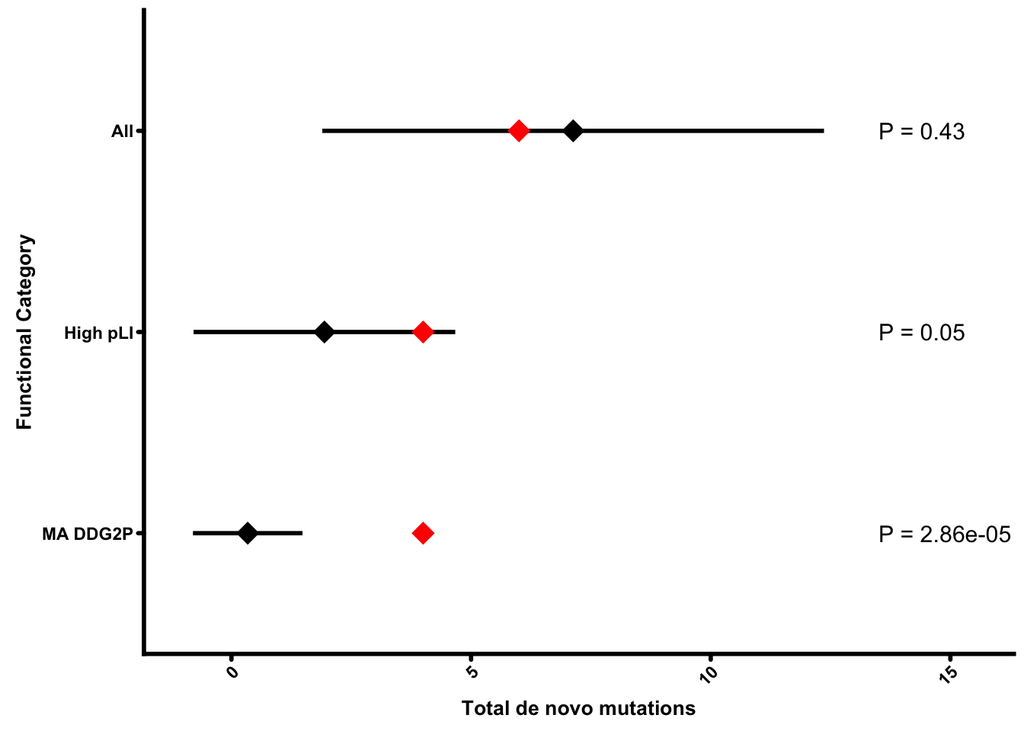

```r
##Load simulation data
sim_data <- fread("RawData/de_novo.test.txt")
setnames(sim_data,names(sim_data),c("exon","exon.pli","exon.ddg2p","intron","intron.pli","intron.ddg2p","enhancer","total"))

##Load MEI data
data.mutations.sum <- data.table(means=c(mean(sim_data[,exon]),mean(sim_data[,exon.pli]),mean(sim_data[,exon.ddg2p]),6,4,4,mean(sim_data[,intron]),mean(sim_data[,intron.pli]),mean(sim_data[,intron.ddg2p]),3,0,0,mean(sim_data[,enhancer]),0),
                                 ci=c(calc.ci(nrow(sim_data),mean(sim_data[,exon])),calc.ci(nrow(sim_data),mean(sim_data[,exon.pli])),calc.ci(nrow(sim_data),mean(sim_data[,exon.ddg2p])),0,0,0,calc.ci(nrow(sim_data),mean(sim_data[,intron])),calc.ci(nrow(sim_data),mean(sim_data[,intron.pli])),calc.ci(nrow(sim_data),mean(sim_data[,intron.ddg2p])),0,0,0,calc.ci(nrow(sim_data),mean(sim_data[,enhancer])),0),
                                 category=c("All","High pLI","MA DDG2P","All","High pLI","MA DDG2P","All","High pLI","MA DDG2P","All","High pLI","MA DDG2P","All","All"),
                                 region=c(rep("Exon",6),rep("Intron",6),rep("Enhancer",2)),
                                 dataset=c(rep("sim",3),rep("real",3),rep("sim",3),rep("real",3),rep("sim",1),rep("real",1)))

## MA = Monoallelic
data.mutations.sum[,category:=factor(category,levels=c("MA DDG2P","High pLI","All"))]
data.mutations.sum[,ci.low:=means-ci]
data.mutations.sum[,ci.high:=means+ci]

##Exon
#Calculate pvalus from the Poisson distribution
#The paste part of the code just formats to the right decimal point if necessary
p.vals<-c()
for (y in c("All","High pLI","MA DDG2P")) {

  if (data.mutations.sum[region=="Exon"][category==y][dataset=="real"][,means] < data.mutations.sum[region=="Exon"][category==y][dataset=="sim"][,means]) {
    val<-ppois(data.mutations.sum[region=="Exon"][category==y][dataset=="real"][,means],data.mutations.sum[region=="Exon"][category==y][dataset=="sim"][,means])
  } else {
    val<-ppois(data.mutations.sum[region=="Exon"][category==y][dataset=="real"][,means],data.mutations.sum[region=="Exon"][category==y][dataset=="sim"][,means],lower.tail=FALSE)
  }
  if (val < 0.01) {
    val<-paste("P = ",sprintf("%.2e",val),sep="")
  } else {
    val<-paste("P = ",sprintf("%.2f",val),sep="")
  }

  p.vals<-c(p.vals,val)

}
p.vals<-data.frame(val=p.vals,category=c("All","High pLI","MA DDG2P"),means=c(13.5,13.5,13.5))

plot.exon<-ggplot(data.mutations.sum[region=="Exon"][dataset=="sim"],aes(means,category),colour="black") +
  geom_point(size=5,shape=18) +
  geom_errorbarh(aes(xmin=ci.low,xmax=ci.high),size=1,height=0) +
  geom_point(data=data.mutations.sum[region=="Exon"][dataset=="real"],inherit.aes=F,aes(means,category),colour="red",size=5,shape=18) +
  ylab("Functional Category") +
  geom_text(data=p.vals,inherit.aes=F,aes(means,category,label=val),size=4,hjust=0) +
  scale_x_continuous(limits = c(-1,15.5),breaks=c(0,5,10,15), name = "Total de novo mutations") +
  theme
plot.exon
```

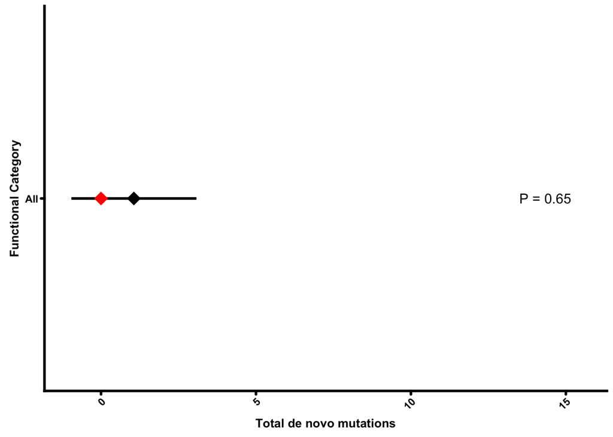

```r
##Enhancer
#Calculate poisson distributions
#The enhancer plot includes all three categories (all, enhancer, MA DDG2P but only prints in all to keep plot sizing the same)
if (data.mutations.sum[region=="Exon"][category==y][dataset=="real"][,means] < data.mutations.sum[region=="Exon"][category==y][dataset=="sim"][,means]) {
  val<-ppois(data.mutations.sum[region=="Enhancer"][category=="All"][dataset=="real"][,means],data.mutations.sum[region=="Enhancer"][category=="All"][dataset=="sim"][,means])
} else {
  val<-ppois(data.mutations.sum[region=="Enhancer"][category=="All"][dataset=="real"][,means],data.mutations.sum[region=="Enhancer"][category=="All"][dataset=="sim"][,means],lower.tail=FALSE)
}
if (val < 0.01) {
  val<-paste("P = ",sprintf("%.2e",val),sep="")
} else {
  val<-paste("P = ",sprintf("%.2f",val),sep="")
}
p.vals<-data.table(val=c(val,"",""),category=factor(c("All","High pLI","MA DDG2P"),levels=c("High pLI","MA DDG2P","All")),means=c(13.5,13.5,13.5))

plot.enh<-ggplot(data.mutations.sum[region=="Enhancer" & dataset=="sim" & category == "All"],aes(means,category),colour="black") +
  geom_point(size=5,shape=18) +
  geom_errorbarh(aes(xmin=ci.low,xmax=ci.high),size=1,height=0) +
  geom_point(data=data.mutations.sum[region=="Enhancer" & dataset=="real" & category == "All"],inherit.aes=F,aes(means,category),colour="red",size=5,shape=18) +
  ylab("Functional Category") +
  geom_text(data=p.vals[category=="All"],inherit.aes=F,aes(means,category,label=val),size=4,hjust=0) +
  scale_x_continuous(limits = c(-1,15.5),breaks=c(0,5,10,15), name = "Total de novo mutations") +
  theme
plot.enh
```

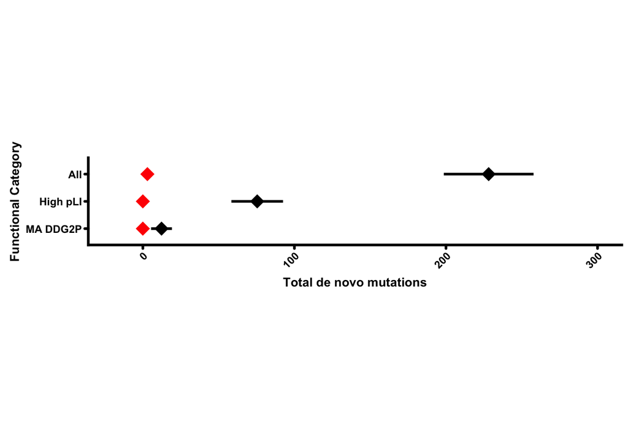

```r
##Introns
plot.int<-ggplot(data.mutations.sum[region=="Intron"][dataset=="sim"],aes(means,category),colour="black") +
  geom_point(size=5,shape=18) +
  geom_errorbarh(aes(xmin=ci.low,xmax=ci.high),size=1,height=0) +
  geom_point(data=data.mutations.sum[region=="Intron"][dataset=="real"],inherit.aes=F,aes(means,category),colour="red",size=5,shape=18) +
  ylab("Functional Category") +
  coord_fixed(ratio=18/1,clip="off") +
  scale_x_continuous(limits = c(-20,300),breaks=c(0,100,200,300), name = "Total de novo mutations") +
  theme
plot.int
```

## Put Figure Together

Still need to edit some things in Illustrator:

- Move the “functional category” label down
- Add Enhancer/Exonic labels
- move “a” and “b”
- Add legend

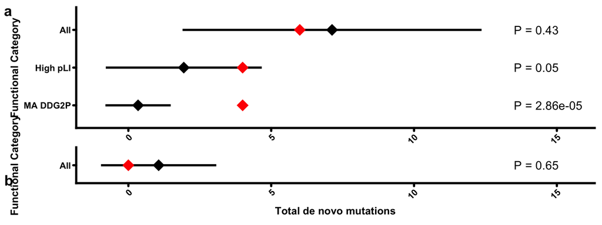

```r
figure4 <- plot_grid(plot.exon,empty,plot.enh,ncol=1,nrow=3,align = 'vh', rel_heights = c(2,-0.35,1), labels = c("a","b"))
figure4
```

# Probability test for nonsense variants

“Coin Flip” testing based on proportion of the genome that is DDG2P and total number of exonic de novos identified (6). We are testing how often these 6 *de novos* identified will hit a DDG2P at the same level we observed (4) in the DDD

This test is based off the total number of BPs in the genome which are:

- Entire (accessible) Genome: 74200000
- Exons: 58608687
- mono DDG2P exons: 2443208

So, in other words how often, by chance, will 4 out of 6 *de novo* MEIs hit known DDG2P exons. This is included in the section on “Mutation Rate” in the manuscript.

**Note:** Remember, this test will result in a slightly different p value every time it is run, so won’t match the number in the paper exactly (should always be in the realm of $10^{-5}$)

```r
acc.genome <- 74200000
dd.mono.exons<-2443208
prob<-(dd.mono.exons/acc.genome)*1000
test<-data.table(trial=c(1:1000000))
ran.samp<-function(z) {
  x<-sample(c(1:1000),6)
  y<-0
  for (t in x) {
    if (t < prob) {
      y<-y+1
    }
  }
  if (y >= 4) {
    return(1)
  } else {
    return(0)
  }
}
test[,val:=mapply(ran.samp,trial)]
final.result<-data.table(table(test[,val]))
p.val<-final.result[V1==1,N]/1000000
paste("Probability of 6 de novo exonic MEIs intersecting known MA-DD exons 4 times is:", p.val)
```

```
## [1] "Probability of 6 de novo exonic MEIs intersecting known MA-DD exons 4 times is: 1.2e-05"
```